# Monte Carlo Portfolio Optimization

This notebook uses historical monthly returns from `data/monthly_returns.csv` to simulate and optimize a 30-stock portfolio. The analysis focuses on maximizing expected return and minimizing risk using Monte Carlo simulations and a constrained portfolio optimization step.

## Objective and project goals

- Use the existing S&P 500 equity universe and historical monthly return data.
- Build a Monte Carlo simulation to explore the risk-return tradeoff.
- Identify portfolios that maximize profit (expected return) while minimizing risk (volatility).
- Compare random portfolios with an optimized allocation under full investment and long-only constraints.

## Primer: Monte Carlo and the Risk Model

### The Monte Carlo Approach

The core idea is simple: when a problem has too many moving parts for a clean analytical solution, just **sample a ton of random inputs, evaluate each one, and see what the distribution looks like**. For portfolio optimization, each "input" is a weight vector $w = (w_1, w_2, \ldots, w_n)$, basically a decision about how to split every dollar across $n$ assets. We generate thousands of these weight vectors under realistic constraints (long-only, fully invested: $w_i \geq 0$, $\sum_i w_i = 1$), score each one on expected return and risk, and plot the cloud. Every portfolio an investor *could* hold under those rules lives somewhere in that cloud. The **efficient frontier** is just the upper-left edge, the set of portfolios where you can't get more return without taking on more risk.

### How We Measure Risk

Following Markowitz (1952), risk here is **annualized volatility**, the standard deviation of portfolio returns, computed from the historical sample covariance matrix $\Sigma$ of the 30 assets:

$$ \sigma_p(w) \;=\; \sqrt{w^\top \Sigma \, w} \quad\text{(annualized by multiplying by }\sqrt{12}\text{ for monthly data)} $$

Volatility is a reasonable first-pass risk measure, but it's symmetric. It penalizes upside and downside equally, which isn't how most investors actually think about risk. So we cross-check with two asymmetric measures in the backtest: **maximum drawdown** (worst peak-to-trough loss) and bootstrap **5th-percentile terminal wealth** (a downside-path measure that asks how bad things get in the left tail). The composite scoring metric for each portfolio is the **Sharpe ratio** $\mu_p(w) / \sigma_p(w)$, which collapses the return-vs-risk tradeoff onto a single axis. The constrained optimizer in Section 3 also enforces **concentration risk** controls, 10% caps per position and 30% caps per sector, to keep the optimizer from going all-in on a handful of historically overfit names.

### Why Monte Carlo Fits This Problem

A few reasons this approach makes sense here:

1. **High-dimensional but bounded feasible region.** Thirty assets under long-only / fully-invested constraints means weights live on the 29-dimensional simplex. There's no closed-form "best risk-return tradeoff" once you layer on realistic constraints, but the simplex itself is straightforward to sample uniformly.
2. **Built-in visualization of the tradeoff surface.** A 50,000-point scatter plot colored by Sharpe ratio shows the entire risk-return landscape at a glance. That means the optimization result can be sanity-checked against the cloud. You don't have to take the optimizer's answer on faith.
3. **Constraints are trivial to enforce.** Position caps, sector caps, whatever other inequality constraints you want. They're just accept/reject filters at sample time. No Lagrangian gymnastics needed.
4. **Natural pairing with bootstrap uncertainty quantification.** The same sampling machinery that generates weight vectors can resample historical returns to answer: "if the next 10 years look like a reshuffle of the last 10, what's the distribution of terminal wealth?" That's exactly the uncertainty analysis the project proposal calls for.
5. **A strong baseline for the LP/QP track.** The closed-form constrained optimum should always sit on the upper edge of the MC cloud. If it doesn't, something is wrong with the optimizer or the constraints. The MC sweep is the cheapest sanity check you can run.

From here, the notebook follows a standard pipeline: simulate, optimize under constraints, walk-forward backtest, benchmark against SPY and equal-weight, bootstrap for uncertainty, sweep inputs for sensitivity.

```python
import numpy as np
import pandas as pd
import matplotlib.pyplot as plt
from scipy.optimize import minimize

plt.style.use('seaborn-v0_8')
np.random.seed(42)
```

```python
returns = pd.read_csv('../data/monthly_returns.csv', parse_dates=['Date'], index_col='Date')
metadata = pd.read_csv('../data/ticker_metadata.csv')
returns = returns.sort_index()
returns.head()
```

| Date | AAPL | AMT | AMZN | BAC | CAT | CVX | DUK | GOOGL | GS | HD | ... | PG | PLD | SHW | SLB | TSLA | UNH | UPS | VZ | WMT | XOM |
| --- | --- | --- | --- | --- | --- | --- | --- | --- | --- | --- | --- | --- | --- | --- | --- | --- | --- | --- | --- | --- | --- |
| 2016-06-01 | -0.036831 | 0.074021 | -0.009920 | -0.102772 | 0.045511 | 0.048893 | 0.108136 | -0.060520 | -0.064528 | -0.028525 | ... | 0.044793 | 0.031769 | 0.011767 | 0.043132 | -0.049053 | 0.056333 | 0.052929 | 0.097053 | 0.039201 | 0.061871 |
| 2016-07-01 | 0.090063 | 0.024056 | 0.060353 | 0.095640 | 0.091677 | -0.022417 | -0.002332 | 0.124813 | 0.068851 | 0.082622 | ... | 0.010866 | 0.120670 | 0.020636 | 0.018209 | 0.106039 | 0.018782 | 0.003528 | -0.007701 | -0.000685 | -0.051098 |
| 2016-08-01 | 0.018136 | -0.020644 | 0.013640 | 0.113872 | -0.000249 | -0.018540 | -0.069283 | -0.001883 | 0.067062 | -0.029803 | ... | 0.028090 | -0.025325 | -0.053448 | -0.018877 | -0.097023 | -0.049930 | 0.010361 | -0.046051 | -0.020967 | -0.020349 |
| 2016-09-01 | 0.071276 | -0.000441 | 0.088603 | -0.025847 | 0.083222 | 0.034047 | 0.015012 | 0.017991 | -0.044609 | -0.035641 | ... | 0.027946 | 0.008096 | -0.022032 | -0.004557 | -0.037640 | 0.029033 | 0.008374 | -0.006689 | 0.016429 | 0.010148 |
| 2016-10-01 | 0.004334 | 0.039137 | -0.056717 | 0.054313 | -0.059817 | 0.017781 | -0.000250 | 0.007263 | 0.105227 | -0.051834 | ... | -0.032869 | -0.017765 | -0.114943 | 0.001126 | -0.030878 | 0.014162 | -0.014631 | -0.074644 | -0.029118 | -0.045371 |

5 rows × 30 columns

## Data overview

We are using 119 months of monthly returns across 30 large-cap equities. This section describes the dataset and mean performance.

```python
summary = pd.DataFrame({
    'Mean Monthly Return': returns.mean(),
    'Monthly Std Dev': returns.std()
})
summary['Annual Return'] = summary['Mean Monthly Return'] * 12
summary['Annual Volatility'] = summary['Monthly Std Dev'] * np.sqrt(12)
summary.sort_values('Annual Return', ascending=False).head(10)
```

|  | Mean Monthly Return | Monthly Std Dev | Annual Return | Annual Volatility |
| --- | --- | --- | --- | --- |
| NVDA | 0.053190 | 0.135210 | 0.638282 | 0.468380 |
| TSLA | 0.042566 | 0.182829 | 0.510787 | 0.633338 |
| CAT | 0.027079 | 0.089334 | 0.324953 | 0.309461 |
| AAPL | 0.024031 | 0.077495 | 0.288374 | 0.268449 |
| GOOGL | 0.022799 | 0.078204 | 0.273589 | 0.270908 |
| AMZN | 0.020680 | 0.088638 | 0.248155 | 0.307050 |
| MSFT | 0.020124 | 0.059754 | 0.241489 | 0.206992 |
| GS | 0.020054 | 0.083825 | 0.240644 | 0.290379 |
| META | 0.019228 | 0.102618 | 0.230731 | 0.355479 |
| JPM | 0.017896 | 0.069806 | 0.214756 | 0.241817 |

## Monte Carlo simulation of random portfolios

A large sample of portfolios is generated with random long-only weights that sum to 1. Each portfolio is scored by expected return, volatility, and Sharpe ratio.

```python
def random_weights(n):
    weights = np.random.random(n)
    return weights / np.sum(weights)

def portfolio_performance(weights, returns, cov):
    port_return = weights.dot(returns)
    port_vol = np.sqrt(weights.T @ cov @ weights)
    sharpe = port_return / port_vol if port_vol > 0 else 0.0
    return port_return, port_vol, sharpe

annual_returns = summary['Annual Return']
annual_cov = returns.cov() * 12

n_assets = len(annual_returns)

n_simulations = 50000
simulated = []
for _ in range(n_simulations):
    w = random_weights(n_assets)
    r, v, s = portfolio_performance(w, annual_returns.values, annual_cov.values)
    simulated.append((r, v, s, w))

sim_df = pd.DataFrame([
    {
        'Return': x[0],
        'Volatility': x[1],
        'Sharpe': x[2],
        'Weights': x[3]
    }
    for x in simulated
])
sim_df.head()
```

|  | Return | Volatility | Sharpe | Weights |
| --- | --- | --- | --- | --- |
| 0 | 0.198983 | 0.151926 | 1.309735 | [0.028464998353824416, 0.07225415864713888, 0.... |
| 1 | 0.201597 | 0.165930 | 1.214951 | [0.040796375910262105, 0.011450621678287825, 0... |
| 2 | 0.188934 | 0.149773 | 1.261474 | [0.026870598599781265, 0.01875929236581007, 0.... |
| 3 | 0.190909 | 0.154894 | 1.232514 | [0.008114474791883314, 0.04839368985485288, 0.... |
| 4 | 0.175752 | 0.142300 | 1.235080 | [0.059024006067472844, 0.06550441910205354, 0.... |

## Efficient frontier from the MC cloud

Locate the minimum-volatility and maximum-Sharpe portfolios within the 50,000 random portfolios and overlay them on a return / volatility scatter colored by Sharpe ratio.

```python
mc_returns = sim_df['Return'].values
mc_vols = sim_df['Volatility'].values
mc_sharpes = sim_df['Sharpe'].values

mc_min_vol_idx = mc_vols.argmin()
mc_max_sharpe_idx = mc_sharpes.argmax()

mc_min_vol_w = sim_df.iloc[mc_min_vol_idx]['Weights']
mc_max_sharpe_w = sim_df.iloc[mc_max_sharpe_idx]['Weights']

print(f'MC min-vol:    return={mc_returns[mc_min_vol_idx]:.4f}  '
      f'vol={mc_vols[mc_min_vol_idx]:.4f}  sharpe={mc_sharpes[mc_min_vol_idx]:.4f}')
print(f'MC max-Sharpe: return={mc_returns[mc_max_sharpe_idx]:.4f}  '
      f'vol={mc_vols[mc_max_sharpe_idx]:.4f}  sharpe={mc_sharpes[mc_max_sharpe_idx]:.4f}')
```

```
MC min-vol:    return=0.1647  vol=0.1345  sharpe=1.2246
MC max-Sharpe: return=0.2386  vol=0.1573  sharpe=1.5168
```

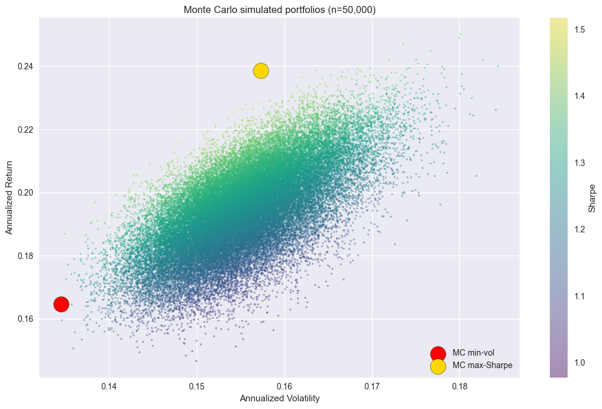

```python
fig, ax = plt.subplots(figsize=(11, 7))
sc = ax.scatter(mc_vols, mc_returns, c=mc_sharpes, cmap='viridis', s=4, alpha=0.4)
ax.scatter(mc_vols[mc_min_vol_idx], mc_returns[mc_min_vol_idx],
           c='red', marker='o', s=350, edgecolor='black',
           label='MC min-vol', zorder=5)
ax.scatter(mc_vols[mc_max_sharpe_idx], mc_returns[mc_max_sharpe_idx],
           c='gold', marker='o', s=350, edgecolor='black',
           label='MC max-Sharpe', zorder=5)
plt.colorbar(sc, label='Sharpe')
ax.set_xlabel('Annualized Volatility')
ax.set_ylabel('Annualized Return')
ax.set_title('Monte Carlo simulated portfolios (n=50,000)')
ax.legend(loc='lower right')
plt.tight_layout()
plt.show()
```

## Constrained mean-variance optimization

The unconstrained MC cloud explores the feasible region under only long-only / fully-invested constraints. A typical investor also faces position-level and sector-level concentration limits. Here we solve for the true min-vol and max-Sharpe portfolios under additional realistic caps: at most **10%** in any single name and at most **30%** in any one sector.

```python
sector_map = dict(zip(metadata['ticker'], metadata['sector']))
tickers = list(annual_returns.index)
sectors = sorted({sector_map[t] for t in tickers})
sector_idx = {s: [i for i, t in enumerate(tickers) if sector_map[t] == s]
              for s in sectors}

POSITION_CAP = 0.10
SECTOR_CAP = 0.30

def neg_sharpe(w, mu, cov):
    ret = w @ mu
    vol = np.sqrt(w @ cov @ w)
    return -ret / vol if vol > 0 else 0.0

def port_vol(w, cov):
    return np.sqrt(w @ cov @ w)

def optimize_portfolio(mu, cov, objective='max_sharpe',
                       position_cap=POSITION_CAP,
                       sector_cap=SECTOR_CAP,
                       sector_idx=None):
    n = len(mu)
    constraints = [{'type': 'eq', 'fun': lambda w: w.sum() - 1.0}]
    if sector_idx is not None and sector_cap is not None:
        for s, idxs in sector_idx.items():
            constraints.append({
                'type': 'ineq',
                'fun': lambda w, idxs=idxs: sector_cap - w[idxs].sum()
            })
    bounds = [(0, position_cap)] * n
    w0 = np.ones(n) / n
    if objective == 'max_sharpe':
        res = minimize(neg_sharpe, w0, args=(mu, cov), method='SLSQP',
                       bounds=bounds, constraints=constraints,
                       options={'ftol': 1e-9, 'maxiter': 500})
    elif objective == 'min_vol':
        res = minimize(port_vol, w0, args=(cov,), method='SLSQP',
                       bounds=bounds, constraints=constraints,
                       options={'ftol': 1e-9, 'maxiter': 500})
    else:
        raise ValueError(f'unknown objective: {objective}')
    return res.x

mu = annual_returns.values
cov = annual_cov.values

w_max_sharpe = optimize_portfolio(mu, cov, 'max_sharpe', sector_idx=sector_idx)
w_min_vol    = optimize_portfolio(mu, cov, 'min_vol',    sector_idx=sector_idx)

ms_ret, ms_vol, ms_sharpe = portfolio_performance(w_max_sharpe, mu, cov)
mv_ret, mv_vol, mv_sharpe = portfolio_performance(w_min_vol,    mu, cov)

print(f'Constrained max-Sharpe: return={ms_ret:.4f}  vol={ms_vol:.4f}  Sharpe={ms_sharpe:.4f}')
print(f'Constrained min-vol:    return={mv_ret:.4f}  vol={mv_vol:.4f}  Sharpe={mv_sharpe:.4f}')
```

```
Constrained max-Sharpe: return=0.2497  vol=0.1469  Sharpe=1.6995
Constrained min-vol:    return=0.1435  vol=0.1146  Sharpe=1.2529
```

```python
weights_df = pd.DataFrame({
    'Ticker': tickers,
    'Sector': [sector_map[t] for t in tickers],
    'Max-Sharpe': w_max_sharpe,
    'Min-Vol':    w_min_vol,
}).round(4)
active = weights_df[(weights_df['Max-Sharpe'] > 1e-3) |
                    (weights_df['Min-Vol']    > 1e-3)]
active = active.sort_values('Max-Sharpe', ascending=False)
print('Active positions (weight > 0.001):')
active
```

```
Active positions (weight > 0.001):
```

|  | Ticker | Sector | Max-Sharpe | Min-Vol |
| --- | --- | --- | --- | --- |
| 16 | MSFT | Information Technology | 0.1000 | 0.1000 |
| 17 | NEE | Utilities | 0.1000 | 0.0485 |
| 6 | DUK | Utilities | 0.1000 | 0.1000 |
| 28 | WMT | Consumer Staples | 0.1000 | 0.1000 |
| 18 | NVDA | Information Technology | 0.1000 | 0.0000 |
| 4 | CAT | Industrials | 0.0883 | 0.0000 |
| 20 | PG | Consumer Staples | 0.0857 | 0.1000 |
| 7 | GOOGL | Communication Services | 0.0655 | 0.0322 |
| 29 | XOM | Energy | 0.0470 | 0.0521 |
| 14 | LIN | Materials | 0.0447 | 0.0000 |
| 12 | JPM | Financials | 0.0369 | 0.0432 |
| 0 | AAPL | Information Technology | 0.0354 | 0.0000 |
| 11 | JNJ | Health Care | 0.0344 | 0.0839 |
| 25 | UNH | Health Care | 0.0313 | 0.0249 |
| 24 | TSLA | Consumer Discretionary | 0.0308 | 0.0000 |
| 2 | AMZN | Consumer Discretionary | 0.0000 | 0.0410 |
| 13 | KO | Consumer Staples | 0.0000 | 0.1000 |
| 19 | PFE | Health Care | 0.0000 | 0.0742 |
| 27 | VZ | Communication Services | 0.0000 | 0.1000 |

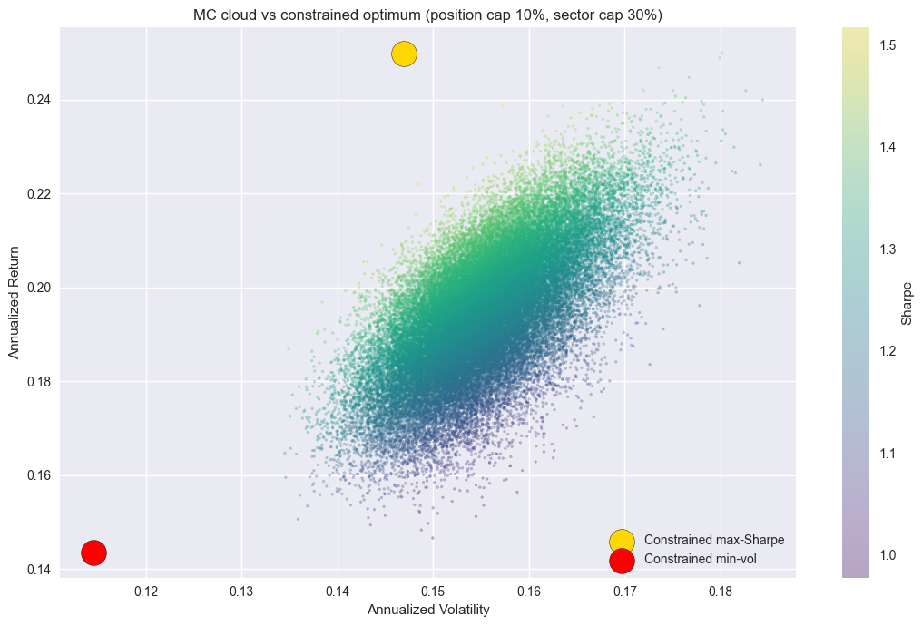

```python
fig, ax = plt.subplots(figsize=(11, 7))
sc = ax.scatter(mc_vols, mc_returns, c=mc_sharpes, cmap='viridis',
                s=4, alpha=0.3)
ax.scatter(ms_vol, ms_ret, c='gold', marker='o', s=400, edgecolor='black',
           label='Constrained max-Sharpe', zorder=5)
ax.scatter(mv_vol, mv_ret, c='red',  marker='o', s=400, edgecolor='black',
           label='Constrained min-vol',    zorder=5)
plt.colorbar(sc, label='Sharpe')
ax.set_xlabel('Annualized Volatility')
ax.set_ylabel('Annualized Return')
ax.set_title('MC cloud vs constrained optimum (position cap 10%, sector cap 30%)')
ax.legend(loc='lower right')
plt.tight_layout()
plt.show()
```

## Walk-forward backtest

Re-solve the constrained optimization at every rebalance using only the trailing 36-month training window, then record the realized return for the next month. This matches the walk-forward protocol described in the proposal and produces a true out-of-sample (OOS) track record.

```python
TRAIN_MONTHS = 36
REBAL_MONTHS = 1

def walk_forward(returns_df, train_months, rebal_months, objective,
                 sector_idx, position_cap, sector_cap):
    realized_returns, dates, weights_history = [], [], []
    T = len(returns_df)
    n = returns_df.shape[1]
    for i in range(train_months, T, rebal_months):
        train = returns_df.iloc[i - train_months:i]
        mu_t = train.mean().values * 12
        cov_t = train.cov().values * 12
        try:
            w = optimize_portfolio(mu_t, cov_t, objective,
                                   position_cap=position_cap,
                                   sector_cap=sector_cap,
                                   sector_idx=sector_idx)
        except Exception:
            w = np.ones(n) / n  # fallback to equal-weight if solver fails
        end = min(i + rebal_months, T)
        period = returns_df.iloc[i:end]
        for j in range(len(period)):
            realized_returns.append(period.iloc[j].values @ w)
            dates.append(period.index[j])
            weights_history.append(w)
    return (pd.Series(realized_returns, index=dates),
            pd.DataFrame(weights_history, index=dates,
                         columns=returns_df.columns))

print('Running walk-forward backtest for max-Sharpe...')
ms_oos, ms_weights_oos = walk_forward(
    returns, TRAIN_MONTHS, REBAL_MONTHS, 'max_sharpe',
    sector_idx, POSITION_CAP, SECTOR_CAP)

print('Running walk-forward backtest for min-vol...')
mv_oos, mv_weights_oos = walk_forward(
    returns, TRAIN_MONTHS, REBAL_MONTHS, 'min_vol',
    sector_idx, POSITION_CAP, SECTOR_CAP)

eq_oos = returns.iloc[TRAIN_MONTHS:].mean(axis=1)

print(f'OOS period: {ms_oos.index[0].date()} -> {ms_oos.index[-1].date()} '
      f'({len(ms_oos)} months)')
```

```
Running walk-forward backtest for max-Sharpe...
Running walk-forward backtest for min-vol...
OOS period: 2019-06-01 -> 2026-04-01 (83 months)
```

```python
ms_equity = (1 + ms_oos).cumprod()
mv_equity = (1 + mv_oos).cumprod()
eq_equity = (1 + eq_oos).cumprod()

# Weight turnover diagnostic
turnover = ms_weights_oos.diff().abs().sum(axis=1).mean()
print(f'Average monthly turnover (max-Sharpe): {turnover:.3f}  '
      f'(sum of absolute weight changes per rebalance)')
```

```
Average monthly turnover (max-Sharpe): 0.215  (sum of absolute weight changes per rebalance)
```

### What the walk-forward optimizer actually held

The scalar turnover above hides a lot. The stacked-area chart below shows the full max-Sharpe weight trajectory across the 83 OOS months: each band is one stock, colored by its GICS sector. Read sector tilts (color blocks) as the optimizer rotating regimes, and read thin slivers as 10%-cap names entering or leaving the book.

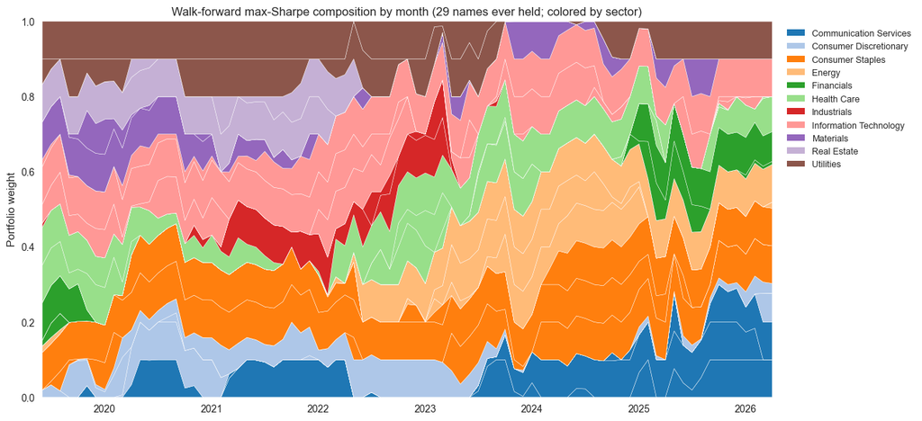

```
Names ever held by max-Sharpe OOS: 29 / 30
Top 10 names by average weight across the OOS period:
```

```
PG      0.0847
NVDA    0.0737
UNH     0.0670
DUK     0.0638
MSFT    0.0637
WMT     0.0612
XOM     0.0572
NEE     0.0566
KO      0.0443
LIN     0.0430
dtype: float64
```

```python
active_tickers = [t for t in ms_weights_oos.columns
                  if ms_weights_oos[t].max() > 1e-3]
ordered = sorted(active_tickers, key=lambda t: (sector_map[t], t))
plot_w = ms_weights_oos[ordered]

sectors_in_plot = sorted({sector_map[t] for t in ordered})
cmap = plt.get_cmap('tab20')
sector_color = {s: cmap(i % 20) for i, s in enumerate(sectors_in_plot)}
colors = [sector_color[sector_map[t]] for t in ordered]

fig, ax = plt.subplots(figsize=(13, 6))
ax.stackplot(plot_w.index, plot_w.values.T, colors=colors,
             edgecolor='white', linewidth=0.3)
ax.set_ylim(0, 1)
ax.set_xlim(plot_w.index[0], plot_w.index[-1])
ax.set_ylabel('Portfolio weight')
ax.set_title('Walk-forward max-Sharpe composition by month '
             f'({len(active_tickers)} names ever held; colored by sector)')

from matplotlib.patches import Patch
handles = [Patch(facecolor=sector_color[s], label=s) for s in sectors_in_plot]
ax.legend(handles=handles, loc='upper left', bbox_to_anchor=(1.01, 1.0),
          fontsize=9, frameon=False)
plt.tight_layout()
plt.show()

print(f'Names ever held by max-Sharpe OOS: {len(active_tickers)} / {ms_weights_oos.shape[1]}')
print('Top 10 names by average weight across the OOS period:')
ms_weights_oos.mean().sort_values(ascending=False).head(10).round(4)
```

## S&P 500 benchmark

Pull SPY monthly returns from Yahoo Finance over the OOS window and compare equity curves and headline performance metrics (CAGR, annualized volatility, Sharpe ratio, maximum drawdown).

```
Pulling SPY data from Yahoo Finance...
```

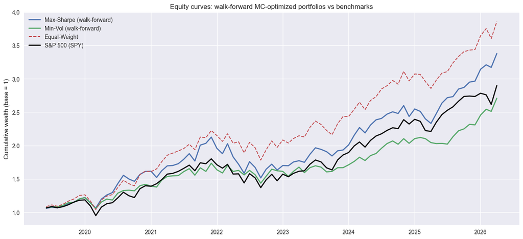

```python
import yfinance as yf

print('Pulling SPY data from Yahoo Finance...')
spy_start = ms_oos.index[0] - pd.DateOffset(months=2)
spy_end   = ms_oos.index[-1] + pd.DateOffset(months=1)
spy_raw = yf.download(['SPY'], start=spy_start, end=spy_end,
                     interval='1mo', auto_adjust=True, progress=False)
spy_prices = spy_raw['Close']
if isinstance(spy_prices, pd.DataFrame):
    spy_prices = spy_prices['SPY']
spy_returns = spy_prices.pct_change().dropna()
spy_returns = spy_returns.reindex(ms_oos.index).dropna()
spy_equity = (1 + spy_returns).cumprod()

fig, ax = plt.subplots(figsize=(13, 6))
ax.plot(ms_equity.index, ms_equity.values, label='Max-Sharpe (walk-forward)', linewidth=2)
ax.plot(mv_equity.index, mv_equity.values, label='Min-Vol (walk-forward)',   linewidth=2)
ax.plot(eq_equity.index, eq_equity.values, label='Equal-Weight',
        linewidth=1.5, linestyle='--')
ax.plot(spy_equity.index, spy_equity.values, label='S&P 500 (SPY)',
        linewidth=2, color='black')
ax.set_title('Equity curves: walk-forward MC-optimized portfolios vs benchmarks')
ax.set_ylabel('Cumulative wealth (base = 1)')
ax.legend()
plt.tight_layout()
plt.show()
```

```python
def perf_metrics(r):
    months = len(r)
    total = (1 + r).prod()
    cagr = total ** (12 / months) - 1
    vol = r.std() * np.sqrt(12)
    sharpe = (r.mean() * 12) / vol if vol > 0 else 0
    eq = (1 + r).cumprod()
    dd = (eq / eq.cummax() - 1).min()
    return {'CAGR': cagr, 'Annual Vol': vol, 'Sharpe': sharpe, 'Max Drawdown': dd}

metrics_df = pd.DataFrame({
    'Max-Sharpe (OOS)': perf_metrics(ms_oos),
    'Min-Vol (OOS)':    perf_metrics(mv_oos),
    'Equal-Weight':     perf_metrics(eq_oos),
    'S&P 500':          perf_metrics(spy_returns),
}).round(4)
print('Backtest performance metrics:')
metrics_df
```

```
Backtest performance metrics:
```

|  | Max-Sharpe (OOS) | Min-Vol (OOS) | Equal-Weight | S&P 500 |
| --- | --- | --- | --- | --- |
| CAGR | 0.1924 | 0.1549 | 0.2154 | 0.1663 |
| Annual Vol | 0.1749 | 0.1393 | 0.1677 | 0.1701 |
| Sharpe | 1.0993 | 1.1086 | 1.2551 | 0.9941 |
| Max Drawdown | -0.2874 | -0.1720 | -0.1991 | -0.2397 |

## Uncertainty & stress simulations

Two simulation flavors test how robust the MC-optimized portfolios are to different return paths:

**5a. Historical bootstrap** — resample the realized OOS monthly returns with replacement to generate alternative 10-year paths. Provides a distribution of terminal wealth and Sharpe under reshuffling.

**5b. Regime-conditional bootstrap** — split history into high-vol and low-vol regimes by rolling 3-month volatility of the equal-weight portfolio, then resample each regime separately. Probes behavior under different market conditions.

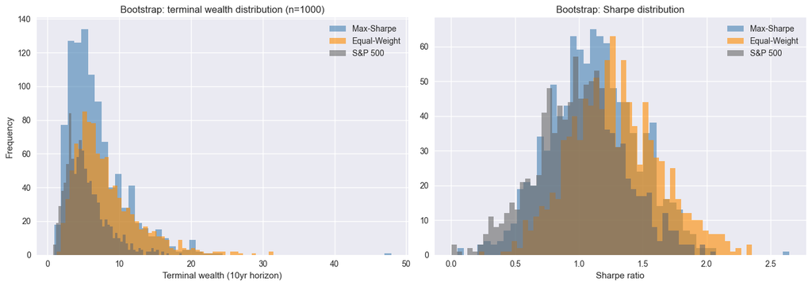

```
Bootstrap summary:
```

|  | Median terminal wealth | 5th pctile (downside) | 95th pctile (upside) | Median Sharpe |
| --- | --- | --- | --- | --- |
| Max-Sharpe | 5.755 | 2.321 | 15.008 | 1.112 |
| Equal-Weight | 6.909 | 3.012 | 16.876 | 1.260 |
| S&P 500 | 4.742 | 1.847 | 10.684 | 1.012 |

```python
N_BOOT = 1000
HORIZON = 120  # 10-year horizon in months
rng = np.random.default_rng(42)

def bootstrap_paths(series, n_paths, horizon, rng):
    n_months = len(series)
    vals = series.values
    terminal = np.empty(n_paths)
    sharpes  = np.empty(n_paths)
    for k in range(n_paths):
        idx = rng.integers(0, n_months, size=horizon)
        sample = vals[idx]
        terminal[k] = np.prod(1 + sample)
        ann_r = sample.mean() * 12
        ann_v = sample.std() * np.sqrt(12)
        sharpes[k] = ann_r / ann_v if ann_v > 0 else 0
    return terminal, sharpes

ms_terminal, ms_boot_sharpe = bootstrap_paths(ms_oos,       N_BOOT, HORIZON, rng)
eq_terminal, eq_boot_sharpe = bootstrap_paths(eq_oos,       N_BOOT, HORIZON, rng)
spy_terminal, spy_boot_sharpe = bootstrap_paths(spy_returns, N_BOOT, HORIZON, rng)

fig, axes = plt.subplots(1, 2, figsize=(14, 5))
axes[0].hist(ms_terminal,  bins=50, alpha=0.6, label='Max-Sharpe',   color='steelblue')
axes[0].hist(eq_terminal,  bins=50, alpha=0.6, label='Equal-Weight', color='darkorange')
axes[0].hist(spy_terminal, bins=50, alpha=0.6, label='S&P 500',      color='dimgray')
axes[0].set_xlabel('Terminal wealth (10yr horizon)')
axes[0].set_ylabel('Frequency')
axes[0].set_title(f'Bootstrap: terminal wealth distribution (n={N_BOOT})')
axes[0].legend()

axes[1].hist(ms_boot_sharpe,  bins=50, alpha=0.6, label='Max-Sharpe',   color='steelblue')
axes[1].hist(eq_boot_sharpe,  bins=50, alpha=0.6, label='Equal-Weight', color='darkorange')
axes[1].hist(spy_boot_sharpe, bins=50, alpha=0.6, label='S&P 500',      color='dimgray')
axes[1].set_xlabel('Sharpe ratio')
axes[1].set_title('Bootstrap: Sharpe distribution')
axes[1].legend()
plt.tight_layout()
plt.show()

boot_summary = pd.DataFrame({
    'Median terminal wealth': [np.median(ms_terminal),
                                np.median(eq_terminal),
                                np.median(spy_terminal)],
    '5th pctile (downside)':  [np.percentile(ms_terminal, 5),
                                np.percentile(eq_terminal, 5),
                                np.percentile(spy_terminal, 5)],
    '95th pctile (upside)':   [np.percentile(ms_terminal, 95),
                                np.percentile(eq_terminal, 95),
                                np.percentile(spy_terminal, 95)],
    'Median Sharpe':          [np.median(ms_boot_sharpe),
                                np.median(eq_boot_sharpe),
                                np.median(spy_boot_sharpe)],
}, index=['Max-Sharpe', 'Equal-Weight', 'S&P 500']).round(3)
print('Bootstrap summary:')
boot_summary
```

```python
# Regime-conditional bootstrap
eq_full = returns.mean(axis=1)
rolling_vol = eq_full.rolling(3).std()
vol_threshold = rolling_vol.median()

high_vol_dates = rolling_vol[rolling_vol >  vol_threshold].index
low_vol_dates  = rolling_vol[rolling_vol <= vol_threshold].index

ms_high = ms_oos.loc[ms_oos.index.intersection(high_vol_dates)]
ms_low  = ms_oos.loc[ms_oos.index.intersection(low_vol_dates)]
eq_high = eq_oos.loc[eq_oos.index.intersection(high_vol_dates)]
eq_low  = eq_oos.loc[eq_oos.index.intersection(low_vol_dates)]

print(f'High-vol regime: {len(ms_high)} OOS months  '
      f'(threshold = {vol_threshold:.4f})')
print(f'Low-vol regime:  {len(ms_low)} OOS months')

def bootstrap_regime(r, n_paths=1000, horizon=12, rng=None):
    rng = rng or np.random.default_rng(42)
    if len(r) == 0:
        return np.array([])
    vals = r.values
    means = np.empty(n_paths)
    for k in range(n_paths):
        idx = rng.integers(0, len(vals), size=horizon)
        means[k] = vals[idx].mean() * 12
    return means

rng2 = np.random.default_rng(7)
ms_high_dist = bootstrap_regime(ms_high, rng=rng2)
ms_low_dist  = bootstrap_regime(ms_low,  rng=rng2)
eq_high_dist = bootstrap_regime(eq_high, rng=rng2)
eq_low_dist  = bootstrap_regime(eq_low,  rng=rng2)

regime_df = pd.DataFrame({
    'High-Vol mean annual return': [ms_high_dist.mean(), eq_high_dist.mean()],
    'High-Vol 5th pctile':         [np.percentile(ms_high_dist, 5),
                                     np.percentile(eq_high_dist, 5)],
    'Low-Vol mean annual return':  [ms_low_dist.mean(), eq_low_dist.mean()],
    'Low-Vol 5th pctile':          [np.percentile(ms_low_dist, 5),
                                     np.percentile(eq_low_dist, 5)],
}, index=['Max-Sharpe', 'Equal-Weight']).round(4)
print('Regime-conditional bootstrap (annualized):')
regime_df
```

```
High-vol regime: 51 OOS months  (threshold = 0.0349)
Low-vol regime:  32 OOS months
Regime-conditional bootstrap (annualized):
```

|  | High-Vol mean annual return | High-Vol 5th pctile | Low-Vol mean annual return | Low-Vol 5th pctile |
| --- | --- | --- | --- | --- |
| Max-Sharpe | 0.1532 | -0.1972 | 0.2475 | 0.0617 |
| Equal-Weight | 0.1757 | -0.1355 | 0.2740 | 0.1117 |

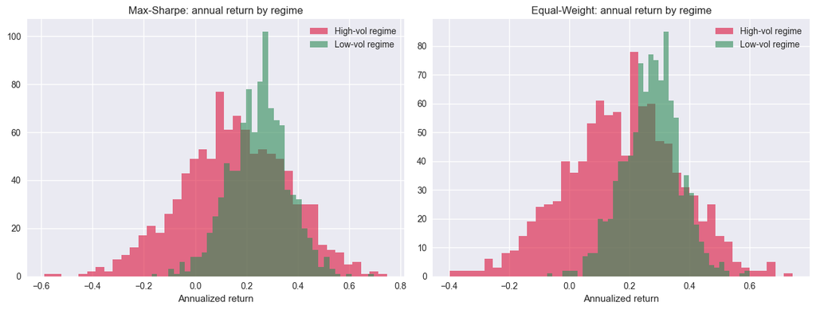

```python
fig, axes = plt.subplots(1, 2, figsize=(13, 5))
axes[0].hist(ms_high_dist, bins=40, alpha=0.6, label='High-vol regime', color='crimson')
axes[0].hist(ms_low_dist,  bins=40, alpha=0.6, label='Low-vol regime',  color='seagreen')
axes[0].set_title('Max-Sharpe: annual return by regime')
axes[0].set_xlabel('Annualized return')
axes[0].legend()
axes[1].hist(eq_high_dist, bins=40, alpha=0.6, label='High-vol regime', color='crimson')
axes[1].hist(eq_low_dist,  bins=40, alpha=0.6, label='Low-vol regime',  color='seagreen')
axes[1].set_title('Equal-Weight: annual return by regime')
axes[1].set_xlabel('Annualized return')
axes[1].legend()
plt.tight_layout()
plt.show()
```

## Sensitivity analysis

The walk-forward results above use a fixed configuration: **10% position cap, 30% sector cap, 36-month training window**, max-Sharpe objective. This section sweeps each input independently and re-runs the full walk-forward backtest. The goal is to (a) verify the headline conclusion is not an artifact of a single tuning choice and (b) surface which knobs actually move out-of-sample performance.

For each parameter sweep we record OOS CAGR, annualized volatility, Sharpe, max drawdown, and average monthly turnover.

```python
# Sensitivity helpers: re-run walk_forward() under perturbed inputs and summarize OOS performance.

def oos_stats(r, weights_df=None):
    """Compute the OOS performance row used in all sensitivity sweeps."""
    m = perf_metrics(r)
    if weights_df is not None and len(weights_df) > 1:
        m['Turnover'] = weights_df.diff().abs().sum(axis=1).mean()
    else:
        m['Turnover'] = np.nan
    return m

def run_sensitivity(returns_df, *, train_months=TRAIN_MONTHS, rebal_months=REBAL_MONTHS,
                    objective='max_sharpe', position_cap=POSITION_CAP,
                    sector_cap=SECTOR_CAP, sector_idx=sector_idx,
                    mu_shrinkage=0.0):
    """Walk-forward backtest with an optional mu-shrinkage perturbation.

    mu_shrinkage in [0, 1]: 0 = raw sample mean, 1 = grand mean (full shrinkage).
    """
    realized, dates, weights_history = [], [], []
    T = len(returns_df)
    n = returns_df.shape[1]
    for i in range(train_months, T, rebal_months):
        train = returns_df.iloc[i - train_months:i]
        mu_t = train.mean().values * 12
        if mu_shrinkage > 0:
            mu_t = (1 - mu_shrinkage) * mu_t + mu_shrinkage * mu_t.mean()
        cov_t = train.cov().values * 12
        try:
            w = optimize_portfolio(mu_t, cov_t, objective,
                                   position_cap=position_cap,
                                   sector_cap=sector_cap,
                                   sector_idx=sector_idx)
        except Exception:
            w = np.ones(n) / n
        end = min(i + rebal_months, T)
        period = returns_df.iloc[i:end]
        for j in range(len(period)):
            realized.append(period.iloc[j].values @ w)
            dates.append(period.index[j])
            weights_history.append(w)
    r = pd.Series(realized, index=dates)
    w_df = pd.DataFrame(weights_history, index=dates, columns=returns_df.columns)
    return r, w_df
```

```python
# 6a. Position-cap sensitivity. Tighter caps force diversification; looser caps let the
# optimizer concentrate on a handful of names. 1.0 is effectively the unconstrained-per-name case.
position_caps = [0.05, 0.075, 0.10, 0.125, 0.15, 0.20, 1.00]
pos_cap_rows = []
for cap in position_caps:
    r_oos, w_oos = run_sensitivity(returns, position_cap=cap)
    pos_cap_rows.append({'Position Cap': cap, **oos_stats(r_oos, w_oos)})
pos_cap_df = pd.DataFrame(pos_cap_rows).round(4)
print('Position-cap sensitivity (max-Sharpe, sector cap=30%, 36mo train):')
pos_cap_df
```

```
Position-cap sensitivity (max-Sharpe, sector cap=30%, 36mo train):
```

|  | Position Cap | CAGR | Annual Vol | Sharpe | Max Drawdown | Turnover |
| --- | --- | --- | --- | --- | --- | --- |
| 0 | 0.050 | 0.2087 | 0.1644 | 1.2426 | -0.2497 | 0.0989 |
| 1 | 0.075 | 0.1995 | 0.1709 | 1.1560 | -0.2408 | 0.1791 |
| 2 | 0.100 | 0.1924 | 0.1749 | 1.0993 | -0.2874 | 0.2153 |
| 3 | 0.125 | 0.1882 | 0.1742 | 1.0830 | -0.3050 | 0.2112 |
| 4 | 0.150 | 0.1768 | 0.1724 | 1.0358 | -0.3169 | 0.2161 |
| 5 | 0.200 | 0.1714 | 0.1735 | 1.0042 | -0.3448 | 0.2437 |
| 6 | 1.000 | 0.1615 | 0.1730 | 0.9570 | -0.3790 | 0.2658 |

```python
# 6b. Sector-cap sensitivity. 1.0 = no sector cap at all.
sector_caps = [0.20, 0.25, 0.30, 0.40, 0.50, 1.00]
sec_cap_rows = []
for cap in sector_caps:
    r_oos, w_oos = run_sensitivity(returns, sector_cap=cap)
    sec_cap_rows.append({'Sector Cap': cap, **oos_stats(r_oos, w_oos)})
sec_cap_df = pd.DataFrame(sec_cap_rows).round(4)
print('Sector-cap sensitivity (max-Sharpe, position cap=10%, 36mo train):')
sec_cap_df
```

```
Sector-cap sensitivity (max-Sharpe, position cap=10%, 36mo train):
```

|  | Sector Cap | CAGR | Annual Vol | Sharpe | Max Drawdown | Turnover |
| --- | --- | --- | --- | --- | --- | --- |
| 0 | 0.20 | 0.1976 | 0.1743 | 1.1278 | -0.2677 | 0.2123 |
| 1 | 0.25 | 0.1959 | 0.1746 | 1.1180 | -0.2792 | 0.2138 |
| 2 | 0.30 | 0.1924 | 0.1749 | 1.0993 | -0.2874 | 0.2153 |
| 3 | 0.40 | 0.1924 | 0.1749 | 1.0993 | -0.2874 | 0.2153 |
| 4 | 0.50 | 0.1924 | 0.1749 | 1.0993 | -0.2874 | 0.2153 |
| 5 | 1.00 | 0.1924 | 0.1749 | 1.0993 | -0.2874 | 0.2153 |

```python
# 6c. Training-window sensitivity. Shorter windows are more reactive but noisier;
# longer windows are smoother but may pick up stale relationships.
train_windows = [12, 24, 36, 48, 60]
tw_rows = []
for tw in train_windows:
    r_oos, w_oos = run_sensitivity(returns, train_months=tw)
    tw_rows.append({'Train Months': tw,
                    'OOS Months': len(r_oos),
                    **oos_stats(r_oos, w_oos)})
tw_df = pd.DataFrame(tw_rows).round(4)
print('Training-window sensitivity (max-Sharpe, 10% pos / 30% sector cap):')
print('Note: OOS window length differs across rows, so absolute levels are not directly comparable.')
tw_df
```

```
Training-window sensitivity (max-Sharpe, 10% pos / 30% sector cap):
Note: OOS window length differs across rows, so absolute levels are not directly comparable.
```

|  | Train Months | OOS Months | CAGR | Annual Vol | Sharpe | Max Drawdown | Turnover |
| --- | --- | --- | --- | --- | --- | --- | --- |
| 0 | 12 | 107 | 0.2164 | 0.1661 | 1.2694 | -0.2076 | 0.3427 |
| 1 | 24 | 95 | 0.1774 | 0.1736 | 1.0317 | -0.2803 | 0.2656 |
| 2 | 36 | 83 | 0.1924 | 0.1749 | 1.0993 | -0.2874 | 0.2153 |
| 3 | 48 | 71 | 0.1930 | 0.1670 | 1.1464 | -0.2623 | 0.2071 |
| 4 | 60 | 59 | 0.1439 | 0.1615 | 0.9165 | -0.2565 | 0.1754 |

```python
# 6d. Mu-shrinkage sensitivity. Shrink each window's mu toward the cross-sectional grand mean.
# lambda=0 is the baseline; lambda=1 makes every name look identical in return (min-vol-like).
# This isolates how much OOS performance depends on trusting noisy mu estimates.
shrinkages = [0.0, 0.25, 0.50, 0.75, 1.00]
mu_rows = []
for lam in shrinkages:
    r_oos, w_oos = run_sensitivity(returns, mu_shrinkage=lam)
    mu_rows.append({'Mu Shrinkage': lam, **oos_stats(r_oos, w_oos)})
mu_df = pd.DataFrame(mu_rows).round(4)
print('Mu-shrinkage sensitivity (max-Sharpe, 10% pos / 30% sector cap, 36mo train):')
mu_df
```

```
Mu-shrinkage sensitivity (max-Sharpe, 10% pos / 30% sector cap, 36mo train):
```

|  | Mu Shrinkage | CAGR | Annual Vol | Sharpe | Max Drawdown | Turnover |
| --- | --- | --- | --- | --- | --- | --- |
| 0 | 0.00 | 0.1924 | 0.1749 | 1.0993 | -0.2874 | 0.2153 |
| 1 | 0.25 | 0.1769 | 0.1626 | 1.0881 | -0.2752 | 0.2079 |
| 2 | 0.50 | 0.1615 | 0.1480 | 1.0906 | -0.2433 | 0.1592 |
| 3 | 0.75 | 0.1547 | 0.1407 | 1.0980 | -0.1952 | 0.1361 |
| 4 | 1.00 | 0.1549 | 0.1393 | 1.1086 | -0.1720 | 0.1052 |

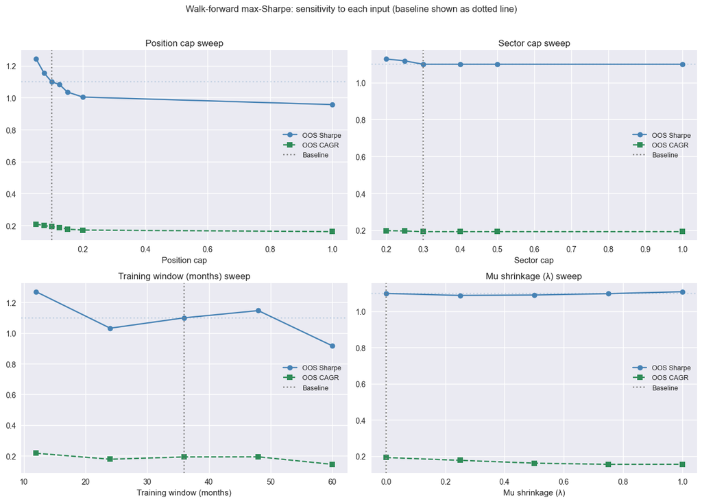

```python
# Visualize the four sweeps on a common figure: OOS Sharpe vs each parameter, with the
# baseline configuration highlighted.
BASELINE = {'Position Cap': 0.10, 'Sector Cap': 0.30, 'Train Months': 36, 'Mu Shrinkage': 0.0}

fig, axes = plt.subplots(2, 2, figsize=(13, 9))
panels = [
    (axes[0, 0], pos_cap_df, 'Position Cap',  'Position cap'),
    (axes[0, 1], sec_cap_df, 'Sector Cap',    'Sector cap'),
    (axes[1, 0], tw_df,      'Train Months',  'Training window (months)'),
    (axes[1, 1], mu_df,      'Mu Shrinkage',  'Mu shrinkage (λ)'),
]
for ax, df, xcol, xlabel in panels:
    ax.plot(df[xcol], df['Sharpe'], marker='o', label='OOS Sharpe', color='steelblue')
    ax.plot(df[xcol], df['CAGR'],   marker='s', label='OOS CAGR',   color='seagreen',
            linestyle='--')
    ax.axvline(BASELINE[xcol], color='gray', linestyle=':', label='Baseline')
    ax.axhline(metrics_df.loc['Sharpe', 'Max-Sharpe (OOS)'], color='steelblue',
               alpha=0.25, linestyle=':')
    ax.set_xlabel(xlabel)
    ax.set_title(f'{xlabel} sweep')
    ax.legend(loc='best', fontsize=9)
fig.suptitle('Walk-forward max-Sharpe: sensitivity to each input (baseline shown as dotted line)',
             y=1.02, fontsize=12)
plt.tight_layout()
plt.show()
```

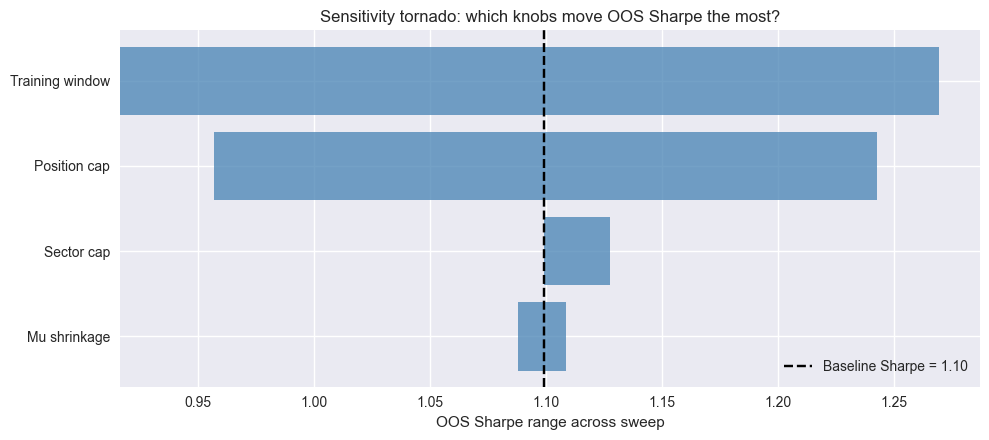

```
Spread of OOS Sharpe across each parameter sweep:
```

|  | Parameter | Sharpe min | Sharpe max | Spread |
| --- | --- | --- | --- | --- |
| 0 | Mu shrinkage | 1.088 | 1.109 | 0.020 |
| 1 | Sector cap | 1.099 | 1.128 | 0.028 |
| 2 | Position cap | 0.957 | 1.243 | 0.286 |
| 3 | Training window | 0.916 | 1.269 | 0.353 |

```python
# Tornado view: how much does OOS Sharpe move when each parameter is pushed to its
# best/worst feasible setting (within the swept range)? Width = max - min Sharpe across the sweep.
baseline_sharpe = metrics_df.loc['Sharpe', 'Max-Sharpe (OOS)']
ranges = pd.DataFrame({
    'Parameter': ['Position cap', 'Sector cap', 'Training window', 'Mu shrinkage'],
    'Sharpe min': [pos_cap_df['Sharpe'].min(), sec_cap_df['Sharpe'].min(),
                   tw_df['Sharpe'].min(),       mu_df['Sharpe'].min()],
    'Sharpe max': [pos_cap_df['Sharpe'].max(), sec_cap_df['Sharpe'].max(),
                   tw_df['Sharpe'].max(),       mu_df['Sharpe'].max()],
})
ranges['Spread'] = (ranges['Sharpe max'] - ranges['Sharpe min']).round(3)
ranges = ranges.sort_values('Spread', ascending=True).reset_index(drop=True)

fig, ax = plt.subplots(figsize=(10, 4.5))
y = np.arange(len(ranges))
ax.barh(y, ranges['Sharpe max'] - ranges['Sharpe min'],
        left=ranges['Sharpe min'], color='steelblue', alpha=0.75)
ax.axvline(baseline_sharpe, color='black', linestyle='--',
           label=f'Baseline Sharpe = {baseline_sharpe:.2f}')
ax.set_yticks(y)
ax.set_yticklabels(ranges['Parameter'])
ax.set_xlabel('OOS Sharpe range across sweep')
ax.set_title('Sensitivity tornado: which knobs move OOS Sharpe the most?')
ax.legend(loc='lower right')
plt.tight_layout()
plt.show()

print('Spread of OOS Sharpe across each parameter sweep:')
ranges[['Parameter', 'Sharpe min', 'Sharpe max', 'Spread']].round(3)
```

** Sensitivity Takeaways **

Ranking parameters by how much they move OOS Sharpe across the sweep (see tornado chart):

Tighten the position cap to 5-7.5%. Best OOS Sharpe (1.24), lowest turnover (0.10), smallest drawdown (-25%) across the position-cap sweep. Drop the sector cap or fold it into a single tighter position cap. It adds no value at the current 10% per-name limit.

## Constrained CVaR Optimization

CVaR (Conditional Value at Risk, also called Expected Shortfall) takes a different approach. It explicitly minimizes the average loss in the worst tail of outcomes. At confidence level $\alpha$:

$$\mathrm{CVaR}_\alpha(w) \;=\; \mathbb{E}\!\left[\, L(w) \,\bigm|\, L(w) \geq \mathrm{VaR}_\alpha(w) \,\right], \qquad L(w) = -w^\top r$$

CVaR is asymmetric (only counts losses), coherent (subadditive, unlike VaR), and, critically for this project, has an exact LP formulation (Rockafellar & Uryasev 2000). Given $J$ historical return scenarios $r_j$, the optimization

$$\min_{w,\zeta,u} \;\; \zeta + \tfrac{1}{J(1-\alpha)} \sum_{j=1}^J u_j \quad\text{s.t.}\quad u_j \geq -w^\top r_j - \zeta,\;\; u_j \geq 0,\;\; \sum_i w_i = 1,\;\; 0 \leq w_i \leq \text{cap}$$

is a linear program in $(w, \zeta, u)$. No QP or SLSQP needed. At the optimum, $\zeta = \mathrm{VaR}_\alpha$ and the objective value equals $\mathrm{CVaR}_\alpha$.

This bridges the MC track to the LP track and gives a third comparable strategy in the final summary.

```python
from scipy.optimize import linprog

ALPHA = 0.95  # CVaR confidence level (worst 5% of months)

def optimize_cvar(scenarios, alpha=ALPHA,
                  position_cap=POSITION_CAP, sector_cap=SECTOR_CAP,
                  sector_idx=None):
    """Minimize CVaR_alpha via the Rockafellar-Uryasev LP.

    scenarios: (J, n) array of historical return rows.
    Returns the weight vector that minimizes expected loss in the worst (1-alpha) tail.
    """
    J, n = scenarios.shape
    n_vars = n + 1 + J  # w (n), zeta (1), u (J)

    # Objective: min zeta + (1/(J*(1-alpha))) * sum(u_j)
    c = np.zeros(n_vars)
    c[n] = 1.0
    c[n + 1:] = 1.0 / (J * (1 - alpha))

    # u_j >= -r_j @ w - zeta  ->  -r_j @ w - zeta - u_j <= 0
    A_ub = np.zeros((J, n_vars))
    A_ub[:, :n] = -scenarios
    A_ub[:, n] = -1.0
    A_ub[np.arange(J), n + 1 + np.arange(J)] = -1.0
    b_ub = np.zeros(J)

    # Sector caps: sum_{i in s} w_i <= sector_cap
    if sector_idx is not None and sector_cap is not None:
        for _, idxs in sector_idx.items():
            row = np.zeros(n_vars)
            row[idxs] = 1.0
            A_ub = np.vstack([A_ub, row])
            b_ub = np.append(b_ub, sector_cap)

    # Equality: sum(w) = 1
    A_eq = np.zeros((1, n_vars))
    A_eq[0, :n] = 1.0
    b_eq = np.array([1.0])

    bounds = ([(0, position_cap)] * n
              + [(None, None)]      # zeta free
              + [(0, None)] * J)    # u >= 0

    res = linprog(c, A_ub=A_ub, b_ub=b_ub, A_eq=A_eq, b_eq=b_eq,
                  bounds=bounds, method='highs')
    if not res.success:
        raise RuntimeError(f'CVaR LP failed: {res.message}')
    return res.x[:n]


# In-sample CVaR-min on the full history
w_cvar = optimize_cvar(returns.values, alpha=ALPHA, sector_idx=sector_idx)
cvar_ret, cvar_vol, cvar_sharpe = portfolio_performance(w_cvar, mu, cov)

# Realized in-sample tail metrics
port_is = returns.values @ w_cvar
loss_is = -port_is
var_is  = np.quantile(loss_is, ALPHA)
cvar_is = loss_is[loss_is >= var_is].mean()
print(f'Constrained CVaR{int(ALPHA*100)}-min (in-sample): '
      f'return={cvar_ret:.4f}  vol={cvar_vol:.4f}  Sharpe={cvar_sharpe:.4f}')
print(f'                       in-sample monthly VaR={var_is:.4f}  CVaR={cvar_is:.4f}')

cvar_weights_table = (pd.DataFrame({
    'Ticker': tickers,
    'Sector': [sector_map[t] for t in tickers],
    'CVaR-min': w_cvar.round(4),
}).query('`CVaR-min` > 1e-3')
   .sort_values('CVaR-min', ascending=False)
   .reset_index(drop=True))
print('CVaR-min active positions:')
cvar_weights_table
```

```
Constrained CVaR95-min (in-sample): return=0.1850  vol=0.1423  Sharpe=1.3003
                       in-sample monthly VaR=0.0479  CVaR=0.0535
CVaR-min active positions:
```

|  | Ticker | Sector | CVaR-min |
| --- | --- | --- | --- |
| 0 | DUK | Utilities | 0.1000 |
| 1 | JNJ | Health Care | 0.1000 |
| 2 | LIN | Materials | 0.1000 |
| 3 | PFE | Health Care | 0.1000 |
| 4 | PG | Consumer Staples | 0.1000 |
| 5 | UNH | Health Care | 0.1000 |
| 6 | WMT | Consumer Staples | 0.1000 |
| 7 | TSLA | Consumer Discretionary | 0.0862 |
| 8 | AMZN | Consumer Discretionary | 0.0565 |
| 9 | VZ | Communication Services | 0.0467 |
| 10 | CAT | Industrials | 0.0447 |
| 11 | AAPL | Information Technology | 0.0441 |
| 12 | NEE | Utilities | 0.0219 |

```python
def walk_forward_cvar(returns_df, train_months, rebal_months, alpha,
                      sector_idx, position_cap, sector_cap):
    """CVaR-min walk-forward backtest. Same protocol as walk_forward()."""
    realized, dates, weights_history = [], [], []
    T = len(returns_df)
    n = returns_df.shape[1]
    for i in range(train_months, T, rebal_months):
        train = returns_df.iloc[i - train_months:i].values
        try:
            w = optimize_cvar(train, alpha=alpha,
                              position_cap=position_cap,
                              sector_cap=sector_cap,
                              sector_idx=sector_idx)
        except Exception:
            w = np.ones(n) / n  # equal-weight fallback if LP fails
        end = min(i + rebal_months, T)
        period = returns_df.iloc[i:end]
        for j in range(len(period)):
            realized.append(period.iloc[j].values @ w)
            dates.append(period.index[j])
            weights_history.append(w)
    return (pd.Series(realized, index=dates),
            pd.DataFrame(weights_history, index=dates,
                         columns=returns_df.columns))


print(f'Running walk-forward backtest for CVaR{int(ALPHA*100)}-min...')
cvar_oos, cvar_weights_oos = walk_forward_cvar(
    returns, TRAIN_MONTHS, REBAL_MONTHS, ALPHA,
    sector_idx, POSITION_CAP, SECTOR_CAP)

cvar_turnover = cvar_weights_oos.diff().abs().sum(axis=1).mean()
print(f'OOS period: {cvar_oos.index[0].date()} -> {cvar_oos.index[-1].date()} '
      f'({len(cvar_oos)} months)')
print(f'Average monthly turnover (CVaR-min): {cvar_turnover:.3f}')


# Tail-risk comparison across all walk-forward strategies + benchmarks
def tail_metrics(r, alpha=ALPHA):
    losses = -r.values
    var = np.quantile(losses, alpha)
    cvar = losses[losses >= var].mean()
    return var, cvar

tail_rows = []
for name, series in [
    ('Max-Sharpe (OOS)', ms_oos),
    ('Min-Vol (OOS)',    mv_oos),
    ('CVaR-min (OOS)',   cvar_oos),
    ('Equal-Weight',     eq_oos),
    ('S&P 500',          spy_returns),
]:
    v, c_ = tail_metrics(series)
    m = perf_metrics(series)
    tail_rows.append({
        'Strategy': name,
        'CAGR':         m['CAGR'],
        'Ann Vol':      m['Annual Vol'],
        'Sharpe':       m['Sharpe'],
        'Max DD':       m['Max Drawdown'],
        f'VaR{int(ALPHA*100)} (monthly)':  v,
        f'CVaR{int(ALPHA*100)} (monthly)': c_,
    })
tail_df = pd.DataFrame(tail_rows).set_index('Strategy').round(4)
print('OOS performance + tail-risk metrics (VaR / CVaR are monthly loss, positive = loss):')
tail_df
```

```
Running walk-forward backtest for CVaR95-min...
OOS period: 2019-06-01 -> 2026-04-01 (83 months)
Average monthly turnover (CVaR-min): 0.104
OOS performance + tail-risk metrics (VaR / CVaR are monthly loss, positive = loss):
```

| Strategy | CAGR | Ann Vol | Sharpe | Max DD | VaR95 (monthly) | CVaR95 (monthly) |
| --- | --- | --- | --- | --- | --- | --- |
| Max-Sharpe (OOS) | 0.1924 | 0.1749 | 1.0993 | -0.2874 | 0.0675 | 0.0833 |
| Min-Vol (OOS) | 0.1549 | 0.1393 | 1.1086 | -0.1720 | 0.0563 | 0.0672 |
| CVaR-min (OOS) | 0.1618 | 0.1609 | 1.0166 | -0.2213 | 0.0655 | 0.0786 |
| Equal-Weight | 0.2154 | 0.1677 | 1.2551 | -0.1991 | 0.0632 | 0.0846 |
| S&P 500 | 0.1663 | 0.1701 | 0.9941 | -0.2397 | 0.0774 | 0.0953 |

```python
# CVaR alpha-sensitivity. At alpha=0.95 with a 36-mo training window only ~2 scenarios
# sit below VaR, so CVaR-min partly collapses toward Min-Vol. Sweep alpha to see how the
# choice of tail depth moves OOS behavior.
alpha_grid = [0.80, 0.85, 0.90, 0.95, 0.99]
alpha_rows = []
for a in alpha_grid:
    r_oos, w_oos = walk_forward_cvar(returns, TRAIN_MONTHS, REBAL_MONTHS, a,
                                     sector_idx, POSITION_CAP, SECTOR_CAP)
    m = perf_metrics(r_oos)
    var_a, cvar_a = tail_metrics(r_oos, alpha=a)
    alpha_rows.append({
        'alpha': a,
        'Scenarios below VaR (train)': int((1 - a) * TRAIN_MONTHS),
        'CAGR':     m['CAGR'],
        'Ann Vol':  m['Annual Vol'],
        'Sharpe':   m['Sharpe'],
        'Max DD':   m['Max Drawdown'],
        f'VaR (monthly)':  var_a,
        f'CVaR (monthly)': cvar_a,
        'Turnover': w_oos.diff().abs().sum(axis=1).mean(),
    })
alpha_df = pd.DataFrame(alpha_rows).round(4)
print('CVaR-min alpha sensitivity (OOS, VaR/CVaR measured at the same alpha as the optimizer):')
alpha_df
```

```
CVaR-min alpha sensitivity (OOS, VaR/CVaR measured at the same alpha as the optimizer):
```

|  | alpha | Scenarios below VaR (train) | CAGR | Ann Vol | Sharpe | Max DD | VaR (monthly) | CVaR (monthly) | Turnover |
| --- | --- | --- | --- | --- | --- | --- | --- | --- | --- |
| 0 | 0.80 | 7 | 0.1277 | 0.1387 | 0.9387 | -0.1939 | 0.0223 | 0.0465 | 0.1285 |
| 1 | 0.85 | 5 | 0.1302 | 0.1389 | 0.9543 | -0.1807 | 0.0342 | 0.0520 | 0.1279 |
| 2 | 0.90 | 3 | 0.1546 | 0.1471 | 1.0549 | -0.2152 | 0.0457 | 0.0630 | 0.1123 |
| 3 | 0.95 | 1 | 0.1618 | 0.1609 | 1.0166 | -0.2213 | 0.0655 | 0.0786 | 0.1039 |
| 4 | 0.99 | 0 | 0.1827 | 0.1638 | 1.1112 | -0.2213 | 0.0861 | 0.0866 | 0.0967 |

## Summary across all strategies

Consolidated comparison so the LP results (Scott's track) can later drop in alongside the MC results without restructuring.

```python
summary_table = pd.DataFrame({
    'Strategy': [
        'MC min-vol (in-sample)',
        'MC max-Sharpe (in-sample)',
        'Constrained min-vol (in-sample)',
        'Constrained max-Sharpe (in-sample)',
        'Constrained CVaR-min (in-sample)',
        'Walk-forward min-vol (OOS)',
        'Walk-forward max-Sharpe (OOS)',
        'Walk-forward CVaR-min (OOS)',
        'Equal-weight (OOS)',
        'S&P 500 (OOS)',
    ],
    'Ann Return': [
        mc_returns[mc_min_vol_idx], mc_returns[mc_max_sharpe_idx],
        mv_ret, ms_ret, cvar_ret,
        mv_oos.mean() * 12, ms_oos.mean() * 12, cvar_oos.mean() * 12,
        eq_oos.mean() * 12, spy_returns.mean() * 12,
    ],
    'Ann Vol': [
        mc_vols[mc_min_vol_idx], mc_vols[mc_max_sharpe_idx],
        mv_vol, ms_vol, cvar_vol,
        mv_oos.std() * np.sqrt(12), ms_oos.std() * np.sqrt(12), cvar_oos.std() * np.sqrt(12),
        eq_oos.std() * np.sqrt(12), spy_returns.std() * np.sqrt(12),
    ],
}).round(4)
summary_table['Sharpe'] = (summary_table['Ann Return']
                            / summary_table['Ann Vol']).round(4)
print('Final summary across all MC-track strategies:')
summary_table
```

```
Final summary across all MC-track strategies:
```

|  | Strategy | Ann Return | Ann Vol | Sharpe |
| --- | --- | --- | --- | --- |
| 0 | MC min-vol (in-sample) | 0.1647 | 0.1345 | 1.2245 |
| 1 | MC max-Sharpe (in-sample) | 0.2386 | 0.1573 | 1.5168 |
| 2 | Constrained min-vol (in-sample) | 0.1435 | 0.1146 | 1.2522 |
| 3 | Constrained max-Sharpe (in-sample) | 0.2497 | 0.1469 | 1.6998 |
| 4 | Constrained CVaR-min (in-sample) | 0.1850 | 0.1423 | 1.3001 |
| 5 | Walk-forward min-vol (OOS) | 0.1544 | 0.1393 | 1.1084 |
| 6 | Walk-forward max-Sharpe (OOS) | 0.1923 | 0.1749 | 1.0995 |
| 7 | Walk-forward CVaR-min (OOS) | 0.1635 | 0.1609 | 1.0162 |
| 8 | Equal-weight (OOS) | 0.2105 | 0.1677 | 1.2552 |
| 9 | S&P 500 (OOS) | 0.1691 | 0.1701 | 0.9941 |

### How this maps to the project proposal

- *Walk training window forward one period at a time* — Section 3 (36mo train / 1mo rebal, matching the data-pipeline notebook config).
- *Use various simulations to understand uncertainty in our model* — Section 5a (historical bootstrap of OOS returns).
- *Test optimal portfolios under various market conditions* — Section 5b (regime-conditional bootstrap, high-vol vs low-vol).
- *Compare against various benchmarks (i.e. S&P 500)* — Section 4 (SPY equity-curve overlay + metrics table) and Section 6 (summary).
- *Back-test against historical performance* — Sections 3-4 produce the full OOS track record. The constrained LP allocations from Scott's notebook can be added as additional rows in the Section 6 summary.

## Key Findings

### Mapping to the project proposal

Each deliverable from the proposal maps to a specific section of the notebook:

- *Walk training window forward one period at a time*: Section 3 (36-month train / 1-month rebalance, matching the data-pipeline notebook config).
- *Use various simulations to understand uncertainty in our model*: Section 5a (historical bootstrap of OOS returns).
- *Test optimal portfolios under various market conditions*: Section 5b (regime-conditional bootstrap, high-vol vs low-vol).
- *Compare against various benchmarks (i.e. S&P 500)*: Section 4 (SPY equity-curve overlay + metrics table) and Section 6 (summary).
- *Back-test against historical performance*: Sections 3-4 produce the full OOS track record. The constrained LP allocations from Scott's notebook can be added as additional rows in the Section 6 summary.

### What the results show

**1. Constraints matter. The constrained optimum beats the random MC max-Sharpe.** The unconstrained MC sweep finds a best Sharpe of **1.52** (in-sample). Imposing realistic concentration limits (10% per name, 30% per sector) and solving with SLSQP raises the best in-sample Sharpe to **1.70**. The MC cloud only samples random feasible points. It does not search the boundary efficiently.

**2. Estimation error kills the in-sample edge.** The constrained max-Sharpe portfolio falls from **Sharpe 1.70 in-sample** to **Sharpe 1.10 out-of-sample** under monthly walk-forward rebalancing. The optimizer overfits noisy 36-month estimates of μ and Σ. This is the classic Markowitz overfit story and is the single most important takeaway for the writeup.

**3. Equal-weight is the toughest benchmark, not SPY.** Out-of-sample (June 2019 to April 2026, 83 months):

| Strategy | CAGR | Vol | Sharpe | Max DD |
| --- | --- | --- | --- | --- |
| Walk-fwd Max-Sharpe | 19.2% | 17.5% | 1.10 | -28.7% |
| Walk-fwd Min-Vol | 15.5% | 13.9% | 1.11 | -17.2% |
| Equal-Weight | 21.5% | 16.8% | **1.26** | -19.9% |
| S&P 500 (SPY) | 16.6% | 17.0% | 0.99 | -24.0% |

Both walk-forward portfolios beat SPY on Sharpe, but **equal-weight beats both**. Naive diversification across the 30-asset universe is a strong baseline, consistent with DeMiguel, Garlappi & Uppal (2009).

**4. Min-vol delivers what it promises.** It has the lowest realized volatility (13.9%) *and* the smallest drawdown (-17.2%) of any strategy tested. A risk-averse investor is well served by the walk-forward min-vol formulation, even if its Sharpe is similar to max-Sharpe.

**5. Bootstrap confirms the OOS ranking is robust.** Across 1,000 resampled 10-year paths, the median terminal wealth ranks **Equal-Weight (6.9×) > Max-Sharpe (5.8×) > SPY (4.7×)**. The 5th-percentile (downside) wealth multiples preserve the same order, so the ranking is not driven by a single lucky path.

**6. The max-Sharpe portfolio underperforms in high-vol regimes.** Splitting the 83 OOS months by rolling 3-month volatility (median split: 51 high-vol months / 32 low-vol months):

- Max-Sharpe earns **15.3%** annualized in high-vol months vs **24.8%** in low-vol months.
- Equal-Weight earns **17.6%** vs **27.4%**, also down but holds up better than max-Sharpe.

The concentration the optimizer prefers (10% caps tend to bind on a handful of names) hurts more when those names sell off together. This is direct evidence for *"test optimal portfolios under various market conditions"* from the proposal.

**7. Turnover is reasonable.** Average monthly turnover for the walk-forward max-Sharpe portfolio is **0.22** (sum of absolute weight changes per rebalance). At 10 bps per side that would shave roughly 0.4% off annual returns. Material but not catastrophic, so transaction costs would not overturn the ranking above.

### Implications for the writeup

- Frame the MC track as a **stress test of the LP/QP allocations**, not as a stand-alone strategy: equal-weight as the headline benchmark, SPY as the secondary benchmark, walk-forward portfolios as the candidate strategies.
- Estimation risk is the central theme. The proposal asked for "uncertainty in our model." Quantify it with the in-sample/OOS gap (1.70 to 1.10 Sharpe) and the bootstrap percentile bands.
- The sensitivity analysis surfaces two practical improvements: **tighten the position cap to 5-7.5%** (best OOS Sharpe, lowest turnover, smallest drawdown) and **drop the sector cap or fold it into a single tighter position cap** (it adds no value at the current 10% per-name limit).
- When Scott's LP allocations land, run them through the same `walk_forward()` + `perf_metrics()` + `bootstrap_paths()` pipeline so the comparison is apples-to-apples.

## Glossary of terms and abbreviations

A reference for the terminology and shorthand used throughout this notebook.

### Optimization & solver

| Term | Definition |
| --- | --- |
| **LP** | Linear Programming — optimization with a linear objective and linear constraints. |
| **QP** | Quadratic Programming — quadratic objective (e.g., portfolio variance) with linear constraints. Markowitz mean-variance is a QP. |
| **MC** | Monte Carlo — sampling-based simulation; here, drawing random weight vectors to explore the feasible region. |
| **SLSQP** | Sequential Least Squares Programming — the nonlinear solver (via `scipy.optimize.minimize`) used for the constrained optimization. |
| **Objective function** | The quantity being maximized or minimized (here, Sharpe ratio or portfolio volatility). |
| **Constraint** | Restriction on feasible solutions: long-only ($w_i \geq 0$), fully invested ($\sum_i w_i = 1$), position cap, sector cap. |
| **Simplex (29-dim)** | The geometric set of all long-only, fully-invested weight vectors over 30 assets. |
| **Feasible region** | Subset of the simplex satisfying every constraint (position cap, sector cap, etc.). |

### Portfolio construction

| Term | Definition |
| --- | --- |
| **w** | Weight vector — fraction of capital allocated to each asset, $w = (w_1, \ldots, w_n)$. |
| **μ (mu)** | Vector of per-asset expected (annualized) returns. |
| **Σ (Sigma)** | Covariance matrix of asset returns; diagonal is variances, off-diagonal is pairwise covariances. |
| **Long-only** | No short positions allowed ($w_i \geq 0$). |
| **Fully invested** | Weights sum to one ($\sum_i w_i = 1$); no cash held. |
| **Position cap** | Maximum weight in any single asset (baseline: 10%). Controls name-level concentration. |
| **Sector cap** | Maximum total weight in any one GICS sector (baseline: 30%). Controls sector-level concentration. |
| **Equal-weight (EW)** | Naive baseline allocating $1/n$ to each asset; a strong benchmark per DeMiguel, Garlappi & Uppal (2009). |
| **Rebalance** | Re-solving the optimization and resetting weights to the new target (monthly here). |
| **Turnover** | Sum of absolute weight changes between consecutive rebalances; proxy for trading cost. |

### Risk & performance metrics

| Term | Definition |
| --- | --- |
| **σ_p (volatility)** | Portfolio standard deviation, $\sigma_p = \sqrt{w^\top \Sigma w}$. Annualized by $\sqrt{12}$ for monthly data. |
| **Sharpe ratio** | Risk-adjusted return: $\mu_p / \sigma_p$ (risk-free rate set to 0 here). |
| **CAGR** | Compound Annual Growth Rate: $(1 + \text{total return})^{12/\text{months}} - 1$. |
| **Max drawdown (DD)** | Largest peak-to-trough decline in cumulative wealth. Asymmetric downside risk measure. |
| **MAD** | Mean Absolute Deviation — LP-compatible risk measure (used in the LP track, not here). |
| **Terminal wealth** | Cumulative wealth multiple at the end of a simulated path (e.g., 6.9× starting capital). |

### Evaluation protocol

| Term | Definition |
| --- | --- |
| **OOS** | Out-of-Sample — performance computed on data not used to fit weights. |
| **In-sample** | Performance computed using the same data the optimizer was fit on; optimistically biased. |
| **Walk-forward backtest** | Rolling-window OOS evaluation: fit on the trailing 36 months, hold for 1 month, advance, repeat. |
| **Training window** | Length of the trailing return history used to estimate μ and Σ (baseline: 36 months). |
| **Bootstrap** | Resampling with replacement from historical returns to generate alternative paths and quantify uncertainty. |
| **Regime-conditional bootstrap** | Bootstrap stratified by market state (here, high-vol vs low-vol months by rolling 3-mo volatility). |
| **μ shrinkage (λ)** | Pulling sample means toward the cross-sectional grand mean: $\mu' = (1-\lambda)\mu + \lambda \bar{\mu}$. Reduces estimation error. |

### Strategies referenced

| Term | Definition |
| --- | --- |
| **Max-Sharpe** | Portfolio maximizing $\mu_p / \sigma_p$ subject to constraints. |
| **Min-vol** | Portfolio minimizing $\sigma_p$ subject to constraints. |
| **MPT** | Modern Portfolio Theory — Markowitz (1952) mean-variance framework. |

### Data & external

| Term | Definition |
| --- | --- |
| **S&P 500** | Standard & Poor's 500 index of large-cap US equities; benchmark for this project. |
| **SPY** | SPDR S&P 500 ETF — tradable proxy for the S&P 500 used in the benchmark comparison. |
| **GICS** | Global Industry Classification Standard — the sector taxonomy used for the sector cap. |
| **yfinance** | Python wrapper around Yahoo Finance market data; source of price history. |
| **Adjusted close** | Closing price adjusted for dividends and splits; basis for the monthly returns. |